# IE 582 - Homework I

### Seval Ata

#### 17.10.2019

**In this homework, we are going to use the English Premier Lig data. At the beginning, I have prepared the data as a data table and add necessary columns for the tasks.**

You can reach the related Jupyter Notebook file from [here](https://github.com/BU-IE-582/fall19-SevalAta/blob/master/files/IE581-HW1-2019-SevalAta.ipynb.json).

*necessary libraries*

```r
library(lubridate)
library(data.table)
library(ggplot2)
library(gridExtra)
library(dplyr)
library(tidyr)
options(warn=-1)
```

*loading the data and turning them into data table format*

```r
matches_file_path="/Users/Seval/Desktop/Dersler/IE582/HW1-2019/matches.csv"
matches=read.csv(matches_file_path)
bets_file_path="/Users/Seval/Desktop/Dersler/IE582/HW1-2019/bets.csv"
bets=read.csv(bets_file_path)
booking_file_path="/Users/Seval/Desktop/Dersler/IE582/HW1-2019/booking.csv"
booking=read.csv(booking_file_path)
goals_file_path="/Users/Seval/Desktop/Dersler/IE582/HW1-2019/goals.csv"
goals=read.csv(goals_file_path)
stats_file_path="/Users/Seval/Desktop/Dersler/IE582/HW1-2019/stats.csv"
stats=read.csv(stats_file_path)

matchesdt=data.table(matches)
betsdt=data.table(bets)
bookingdt=data.table(booking)
goalsdt=data.table(goals)
statsdt=data.table(stats)
```

*adding new column to the data: difference_of_scores*  
filtering the data for only English Premier League data  
removing the matches that are not finished yet

```r
matchesdt$match_hometeam_score=as.numeric(matchesdt$match_hometeam_score)
matchesdt$match_awayteam_score=as.numeric(matchesdt$match_awayteam_score)
matchesdt[,difference_of_scores:=match_hometeam_score-match_awayteam_score]
matchesdtEPL=matchesdt[league_id==148]
matchesdtEPL=matchesdtEPL[!match_status=="NA"]
```

# Task 1

In this task we are going to analyze the distribution of the data. Therefore, I prepared the following histograms for Home Scores, Away Scores and the difference of them.

## Part 1

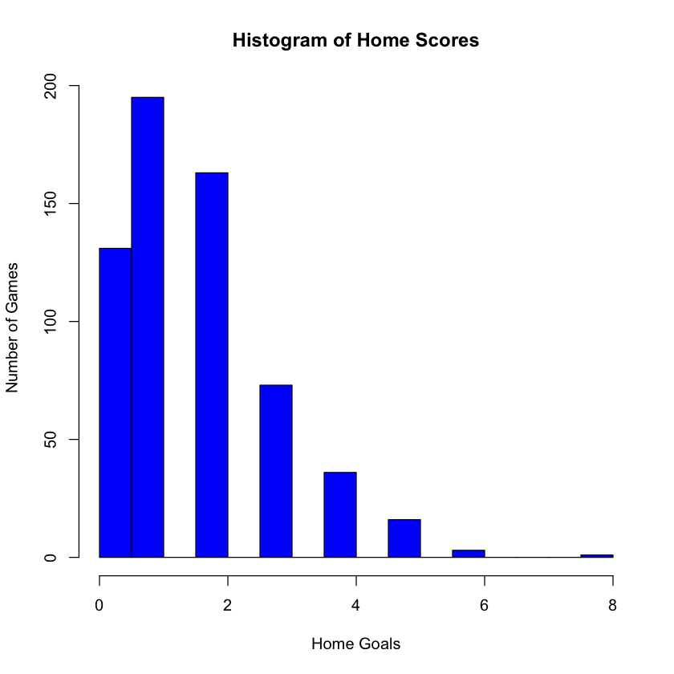

```r
hist(matchesdtEPL$match_hometeam_score, breaks=16, xlab="Home Goals", ylab= "Number of Games",main="Histogram of Home Scores",col="blue")
```

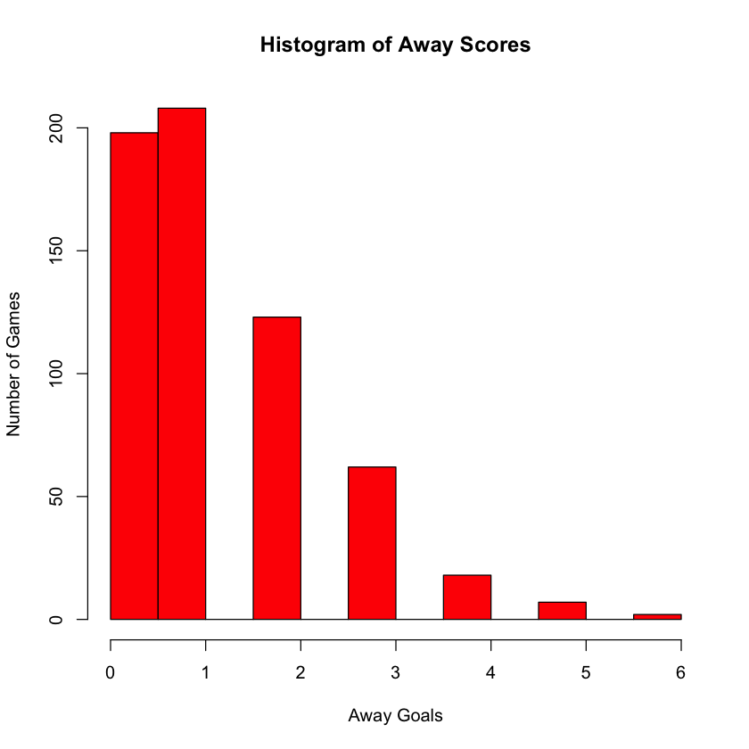

```r
hist(matchesdtEPL$match_awayteam_score, breaks=12, xlab="Away Goals", ylab= "Number of Games",main="Histogram of Away Scores", col="red")
```

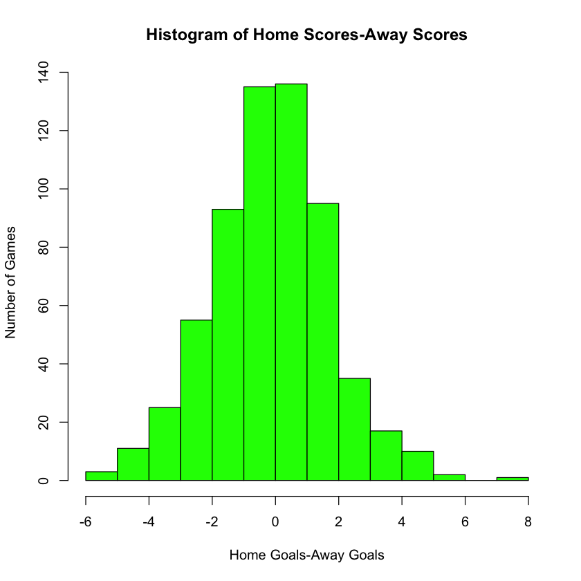

```r
hist(matchesdtEPL$difference_of_scores,xlab="Home Goals-Away Goals", ylab= "Number of Games",main="Histogram of Home Scores-Away Scores", col="green")
```

## Part 2

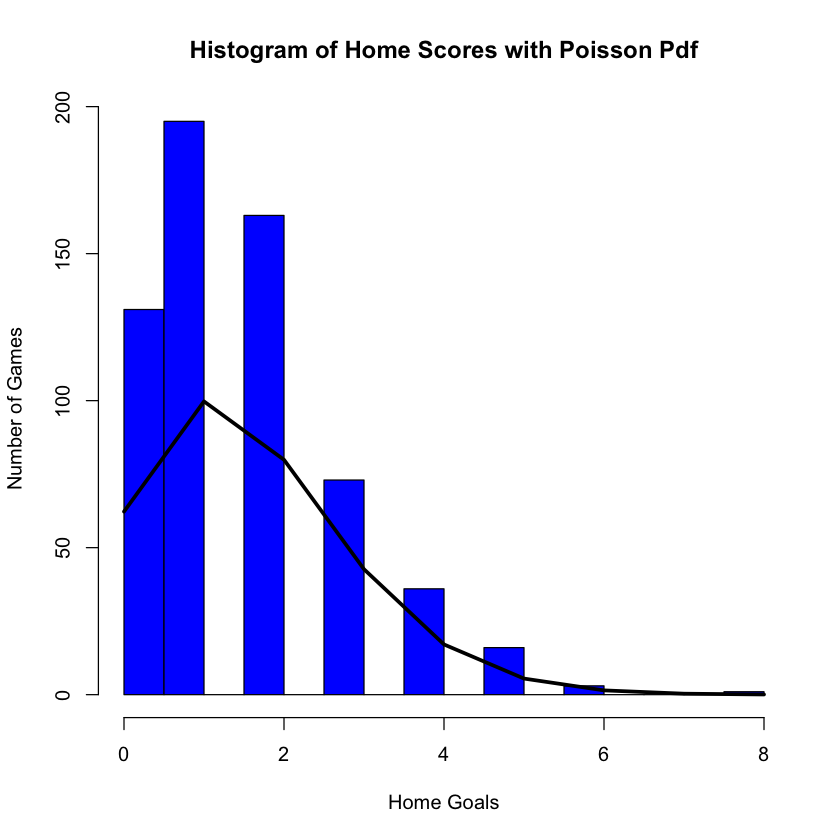

```r
h1<-hist(matchesdtEPL$match_hometeam_score,breaks=16,xlab="Home Goals", ylab= "Number of Games",main="Histogram of Home Scores with Poisson Pdf", col="blue")
xhist1<-c(min(h1$breaks),h1$breaks)
yhist1<-c(0,h1$density,0)
xfit1<-seq(min(matchesdtEPL$match_hometeam_score),max(matchesdtEPL$match_hometeam_score),by=1)
yfit1<-dpois(xfit1,lambda=mean(matchesdtEPL$match_hometeam_score), log=FALSE)
yfit1 <- yfit1*diff(h1$mids[1:2])*length(matchesdtEPL$match_hometeam_score)
lines(xfit1, yfit1, col="black", lwd=3)
```

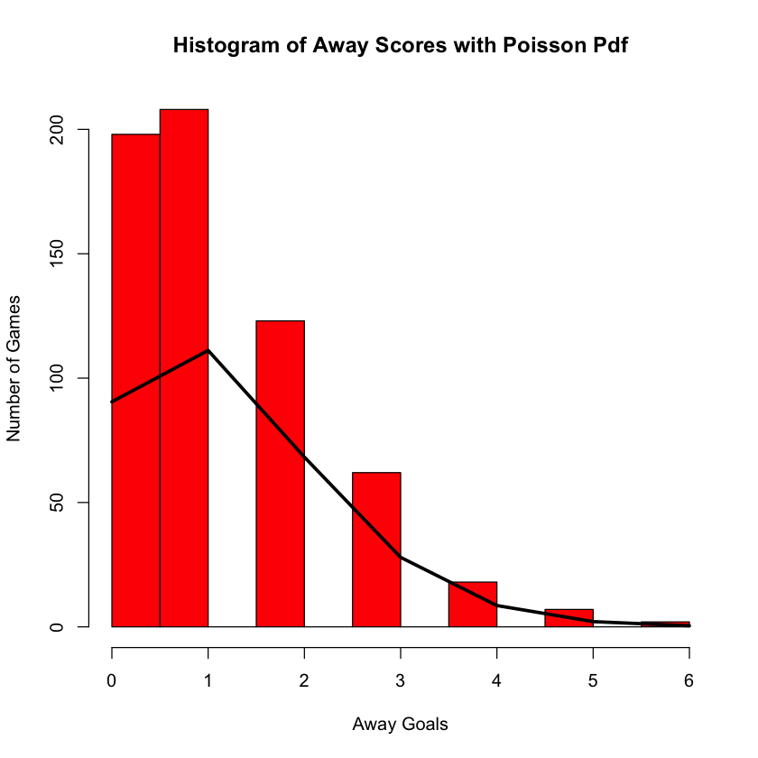

```r
h2<-hist(matchesdtEPL$match_awayteam_score,breaks=12,xlab="Away Goals", ylab= "Number of Games",main="Histogram of Away Scores with Poisson Pdf", col="red")
xhist2<-c(min(h2$breaks),h2$breaks)
yhist2<-c(0,h2$density,0)
xfit2<-seq(min(matchesdtEPL$match_awayteam_score),max(matchesdtEPL$match_awayteam_score),by=1)
yfit2<-dpois(xfit2,lambda=mean(matchesdtEPL$match_awayteam_score), log=FALSE)
yfit2 <- yfit2*diff(h2$mids[1:2])*length(matchesdtEPL$match_awayteam_score)
lines(xfit2, yfit2, col="black", lwd=3)
```

# Task 2

The aim of this task is to understand if bookmakers are good enough in setting their odds for “draw” bets. I selected the following 4 bookmakers for this task: **1xBet, Marathonbet, BetVictor, Betclic.**

*adding a new column as IsDraw to indicate whether a match is finished as tie or not*

```r
matchesdtEPL[,IsDraw:=0]
matchesdtEPL[match_hometeam_score==match_awayteam_score,IsDraw:=1]
```

*merging bets and matches data and calculating probability of home win, away win or draw probability as 1/odd*

```r
merged_matches_bets=merge(matchesdtEPL,betsdt,by='match_id')
merged_matches_bets=merged_matches_bets[,probability:=1/value]
```

*separating the bookmakers' data*

```r
merged_matches_bets_1xBet=merged_matches_bets[odd_bookmakers=="1xBet"]
merged_matches_bets_Marathonbet=merged_matches_bets[odd_bookmakers=="Marathonbet"]
merged_matches_bets_BetVictor=merged_matches_bets[odd_bookmakers=="BetVictor"]
merged_matches_bets_Betclic=merged_matches_bets[odd_bookmakers=="Betclic"]
```

*separating the home-win, draw and away-win data of each bookmakers*

```r
merged_matches_bets_1xBet_homewin=merged_matches_bets_1xBet[variable=="odd_1"]
merged_matches_bets_1xBet_draw=merged_matches_bets_1xBet[variable=="odd_x"]
merged_matches_bets_1xBet_awaywin=merged_matches_bets_1xBet[variable=="odd_2"]

merged_matches_bets_Marathonbet_homewin=merged_matches_bets_Marathonbet[variable=="odd_1"]
merged_matches_bets_Marathonbet_draw=merged_matches_bets_Marathonbet[variable=="odd_x"]
merged_matches_bets_Marathonbet_awaywin=merged_matches_bets_Marathonbet[variable=="odd_2"]

merged_matches_bets_BetVictor_homewin=merged_matches_bets_BetVictor[variable=="odd_1"]
merged_matches_bets_BetVictor_draw=merged_matches_bets_BetVictor[variable=="odd_x"]
merged_matches_bets_BetVictor_awaywin=merged_matches_bets_BetVictor[variable=="odd_2"]

merged_matches_bets_Betclic_homewin=merged_matches_bets_Betclic[variable=="odd_1"]
merged_matches_bets_Betclic_draw=merged_matches_bets_Betclic[variable=="odd_x"]
merged_matches_bets_Betclic_awaywin=merged_matches_bets_Betclic[variable=="odd_2"]
```

*adding home-win, draw and away-win probabilities of the every matches given by four bookmakers as the new columns*

```r
merged_1xBet=merged_matches_bets_1xBet_homewin
names(merged_1xBet)[24]="home_win_probability"
merged_1xBet$draw_probability<-NA
merged_1xBet$draw_probability<-merged_matches_bets_1xBet_draw$probability
merged_1xBet$away_win_probability<-NA
merged_1xBet$away_win_probability<-merged_matches_bets_1xBet_awaywin$probability

merged_Marathonbet=merged_matches_bets_Marathonbet_homewin
names(merged_Marathonbet)[24]="home_win_probability"
merged_Marathonbet$draw_probability<-NA
merged_Marathonbet$draw_probability<-merged_matches_bets_Marathonbet_draw$probability
merged_Marathonbet$away_win_probability<-NA
merged_Marathonbet$away_win_probability<-merged_matches_bets_Marathonbet_awaywin$probability

merged_BetVictor=merged_matches_bets_BetVictor_homewin
names(merged_BetVictor)[24]="home_win_probability"
merged_BetVictor$draw_probability<-NA
merged_BetVictor$draw_probability<-merged_matches_bets_BetVictor_draw$probability
merged_BetVictor$away_win_probability<-NA
merged_BetVictor$away_win_probability<-merged_matches_bets_BetVictor_awaywin$probability

merged_Betclic=merged_matches_bets_Betclic_homewin
names(merged_Betclic)[24]="home_win_probability"
merged_Betclic$draw_probability<-NA
merged_Betclic$draw_probability<-merged_matches_bets_Betclic_draw$probability
merged_Betclic$away_win_probability<-NA
merged_Betclic$away_win_probability<-merged_matches_bets_Betclic_awaywin$probability
```

*calculating the home-win, draw and away-win probabilities again by normalization*

```r
merged_1xBet=merged_1xBet[,implied_home_win_probability:=merged_1xBet$home_win_probability/(merged_1xBet$home_win_probability+merged_1xBet$draw_probability+merged_1xBet$away_win_probability)]
merged_1xBet=merged_1xBet[,implied_draw_probability:=merged_1xBet$draw_probability/(merged_1xBet$home_win_probability+merged_1xBet$draw_probability+merged_1xBet$away_win_probability)]
merged_1xBet=merged_1xBet[,implied_away_win_probability:=merged_1xBet$away_win_probability/(merged_1xBet$home_win_probability+merged_1xBet$draw_probability+merged_1xBet$away_win_probability)]
merged_1xBet=merged_1xBet[,p_home_minus_p_away:=home_win_probability-away_win_probability]

merged_Marathonbet=merged_Marathonbet[,implied_home_win_probability:=merged_Marathonbet$home_win_probability/(merged_Marathonbet$home_win_probability+merged_Marathonbet$draw_probability+merged_Marathonbet$away_win_probability)]
merged_Marathonbet=merged_Marathonbet[,implied_draw_probability:=merged_Marathonbet$draw_probability/(merged_Marathonbet$home_win_probability+merged_Marathonbet$draw_probability+merged_Marathonbet$away_win_probability)]
merged_Marathonbet=merged_Marathonbet[,implied_away_win_probability:=merged_Marathonbet$away_win_probability/(merged_Marathonbet$home_win_probability+merged_Marathonbet$draw_probability+merged_Marathonbet$away_win_probability)]
merged_Marathonbet=merged_Marathonbet[,p_home_minus_p_away:=home_win_probability-away_win_probability]

merged_BetVictor=merged_BetVictor[,implied_home_win_probability:=merged_BetVictor$home_win_probability/(merged_BetVictor$home_win_probability+merged_BetVictor$draw_probability+merged_BetVictor$away_win_probability)]
merged_BetVictor=merged_BetVictor[,implied_draw_probability:=merged_BetVictor$draw_probability/(merged_BetVictor$home_win_probability+merged_BetVictor$draw_probability+merged_BetVictor$away_win_probability)]
merged_BetVictor=merged_BetVictor[,implied_away_win_probability:=merged_BetVictor$away_win_probability/(merged_BetVictor$home_win_probability+merged_BetVictor$draw_probability+merged_BetVictor$away_win_probability)]
merged_BetVictor=merged_BetVictor[,p_home_minus_p_away:=home_win_probability-away_win_probability]

merged_Betclic=merged_Betclic[,implied_home_win_probability:=merged_Betclic$home_win_probability/(merged_Betclic$home_win_probability+merged_Betclic$draw_probability+merged_Betclic$away_win_probability)]
merged_Betclic=merged_Betclic[,implied_draw_probability:=merged_Betclic$draw_probability/(merged_Betclic$home_win_probability+merged_Betclic$draw_probability+merged_Betclic$away_win_probability)]
merged_Betclic=merged_Betclic[,implied_away_win_probability:=merged_Betclic$away_win_probability/(merged_Betclic$home_win_probability+merged_Betclic$draw_probability+merged_Betclic$away_win_probability)]
merged_Betclic=merged_Betclic[,p_home_minus_p_away:=home_win_probability-away_win_probability]
```

*ordering the data according to P(home win)-P(away win)*

```r
merged_1xBet=merged_1xBet[order(p_home_minus_p_away)]
merged_Marathonbet=merged_Marathonbet[order(p_home_minus_p_away)]
merged_BetVictor=merged_BetVictor[order(p_home_minus_p_away)]
merged_Betclic=merged_Betclic[order(p_home_minus_p_away)]
```

*discretizing P(home win) – P(away win) values into bins*

```r
cutpoints=seq(-1,1,0.2)
merged_1xBet[,cut_probability_diff:=cut(p_home_minus_p_away,cutpoints)]
merged_Marathonbet[,cut_probability_diff:=cut(p_home_minus_p_away,cutpoints)]
merged_BetVictor[,cut_probability_diff:=cut(p_home_minus_p_away,cutpoints)]
merged_Betclic[,cut_probability_diff:=cut(p_home_minus_p_away,cutpoints)]
```

*calculating the estimated probability of draws*

```r
summary_table1=merged_1xBet[,list(empirical_draw=mean(IsDraw),
                                   probabilistic_draw=mean(p_home_minus_p_away),.N),
                             by=list(cut_probability_diff)]

summary_table2=merged_Marathonbet[,list(empirical_draw=mean(IsDraw),
                                   probabilistic_draw=mean(p_home_minus_p_away),.N),
                             by=list(cut_probability_diff)]

summary_table3=merged_BetVictor[,list(empirical_draw=mean(IsDraw),
                                   probabilistic_draw=mean(p_home_minus_p_away),.N),
                             by=list(cut_probability_diff)]

summary_table4=merged_Betclic[,list(empirical_draw=mean(IsDraw),
                                   probabilistic_draw=mean(p_home_minus_p_away),.N),
                             by=list(cut_probability_diff)]
```

**Plot of P(home win) – P(away win) on x-axis and P (draw) on y-axis with first probability calculation for each bookmaker is given below. The black points show the individual data, and the blue line shows the trend line. The actual probabilities which are calculated using the results are added to the plot as the colored points.**

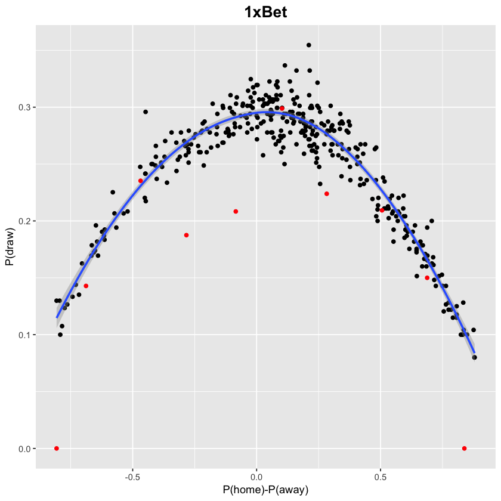

```r
plot1=ggplot(merged_1xBet, aes(x=p_home_minus_p_away,y=draw_probability)) + geom_point() + geom_smooth() + ggtitle("1xBet") +
xlab("P(home)-P(away)") + ylab("P(draw)")+ theme(plot.title = element_text(hjust=0.5, face="bold", size = 16))
plot1= plot1 +geom_point(summary_table1, mapping = aes(x=probabilistic_draw, y=empirical_draw), colour="red")
plot1
```

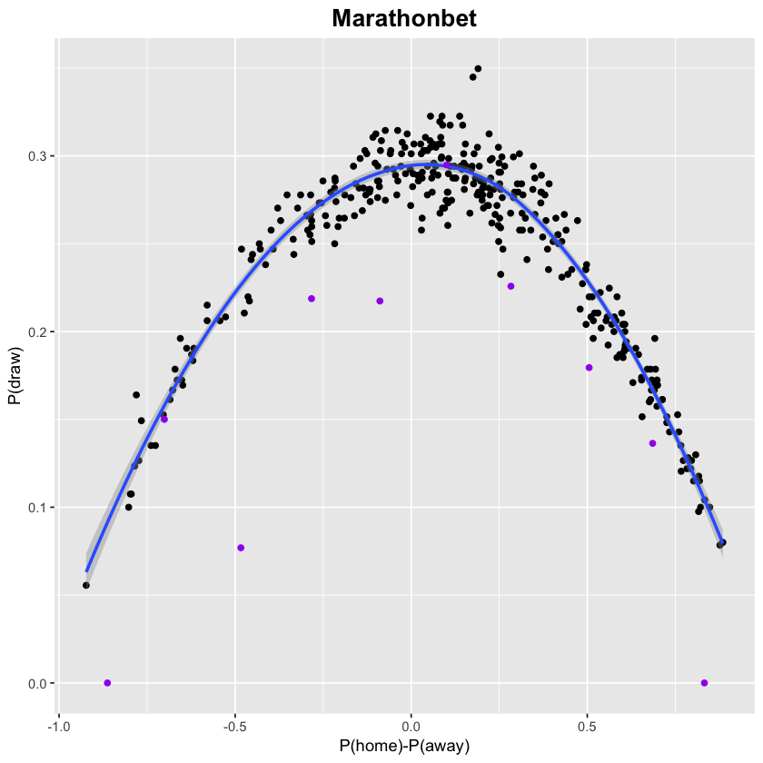

```r
plot2=ggplot(merged_Marathonbet, aes(x=p_home_minus_p_away,y=draw_probability)) + geom_point() + geom_smooth()  + ggtitle("Marathonbet") +
xlab("P(home)-P(away)") + ylab("P(draw)")+ theme(plot.title = element_text(hjust=0.5, face="bold", size = 16))
plot2= plot2 +geom_point(summary_table2, mapping = aes(x=probabilistic_draw, y=empirical_draw), colour="purple")
plot2
```

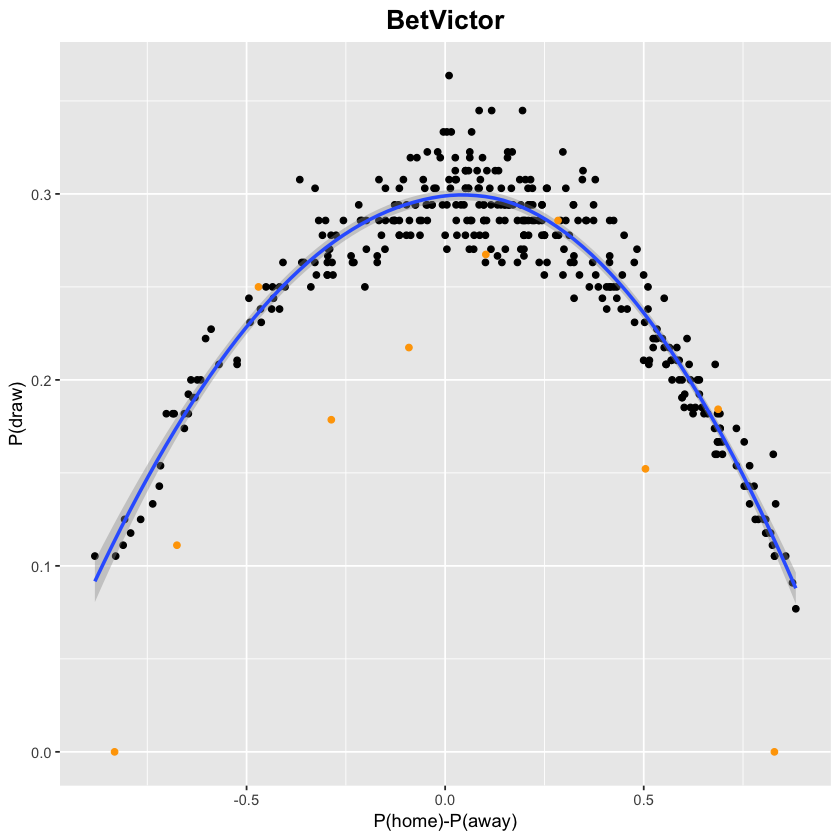

```r
plot3=ggplot(merged_BetVictor, aes(x=p_home_minus_p_away,y=draw_probability)) + geom_point() + geom_smooth()  + ggtitle("BetVictor") +
xlab("P(home)-P(away)") + ylab("P(draw)")+ theme(plot.title = element_text(hjust=0.5, face="bold", size = 16))
plot3= plot3 +geom_point(summary_table3, mapping = aes(x=probabilistic_draw, y=empirical_draw), colour="orange")
plot3
```

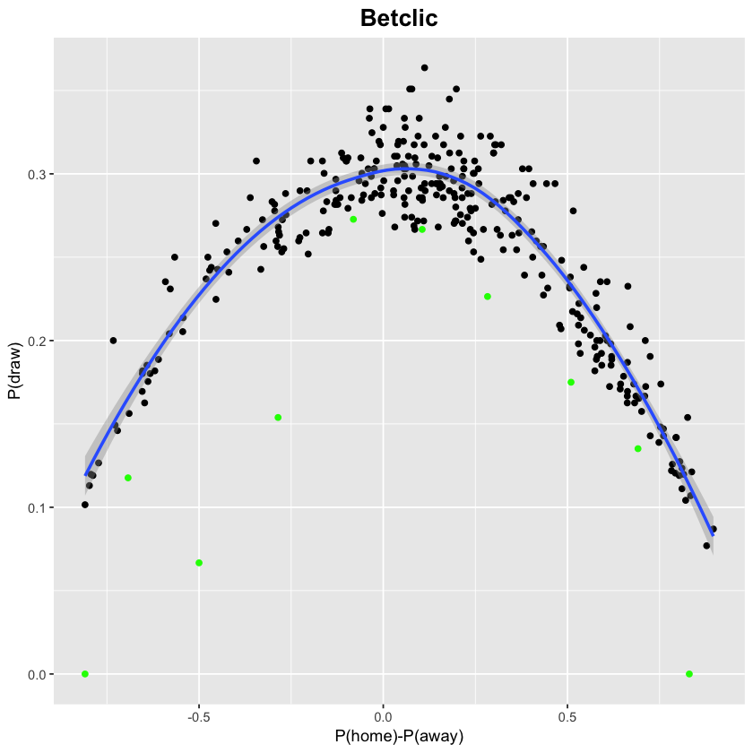

```r
plot4=ggplot(merged_Betclic, aes(x=p_home_minus_p_away,y=draw_probability)) + geom_point() + geom_smooth()  + ggtitle("Betclic") +
xlab("P(home)-P(away)") + ylab("P(draw)")+ theme(plot.title = element_text(hjust=0.5, face="bold", size = 16))
plot4= plot4 +geom_point(summary_table4, mapping = aes(x=probabilistic_draw, y=empirical_draw), colour="green")
plot4
```

**We can see that many of the bins for even games, where P(home) − P(away) ≈ 0, are below the odds trend line. Therefore, we can conclude that one is not expected to make money in the long run by betting on “Draw” for the games whose odds reside in the corresponding bin.**

# Task 3

In this task, I am going to eliminate the matches with two cases as following:

- Case 1: matches when a red card is given in the first 30 minutes
- Case 2: matches when a team wins with a goal or goals after 90th minute or match ends draw or away because of the same reason

*adding the columns of both goals and bookings data to the existing data*

```r
merged_1xBet_revised=merge(merged_1xBet,goalsdt,by='match_id')
merged_1xBet_revised=merge(merged_1xBet_revised,bookingdt,by='match_id')
```

*renaming the name of time variables coming from two different data to get rid of the confusion*

```r
names(merged_1xBet_revised)[32]<-"goal_time"
names(merged_1xBet_revised)[36]<-"card_time"
```

*separating the time of the goal variable into normal time and extra time for the data in a format such as 90+3 or 45+1*

```r
merged_1xBet_revised=separate(data = merged_1xBet_revised, col = goal_time, into = c("Goal_Normal_time", "Goal_Extra_time"), sep = "\\+")
merged_1xBet_revised=separate(data = merged_1xBet_revised, col = card_time, into = c("Card_Normal_time", "Card_Extra_time"), sep = "\\+")
```

*changing the type of the goal time variable to numeric data*

```r
merged_1xBet_revised$Goal_Extra_time=as.numeric(merged_1xBet_revised$Goal_Extra_time)
merged_1xBet_revised[is.na(Goal_Extra_time)]$Goal_Extra_time<-0
merged_1xBet_revised$Card_Extra_time=as.numeric(merged_1xBet_revised$Card_Extra_time)
merged_1xBet_revised[is.na(Card_Extra_time)]$Card_Extra_time<-0
```

*splitting the score variable into HomeGoals and AwayGoals to be able to their difference*

```r
merged_1xBet_revised=merged_1xBet_revised[,c("HomeGoals","AwayGoals"):=tstrsplit(score,'-')]
merged_1xBet_revised$HomeGoals=as.numeric(merged_1xBet_revised$HomeGoals)
merged_1xBet_revised$AwayGoals=as.numeric(merged_1xBet_revised$AwayGoals)
merged_1xBet_revised=merged_1xBet_revised[,Difference:=HomeGoals-AwayGoals]
```

*the number of matches that 1xBet gave odds for*

```r
number_of_matches_1xBet=dim(unique(data.table(merged_1xBet_revised$match_id)))[1]
number_of_matches_1xBet
```

219

*the number of matches which are going to be eliminated as the Case 1*

```r
matches_to_remove_case1_1xBet=merged_1xBet_revised[Card_Normal_time<=30 & card=="red card"]
number_of_removed_matches_case1_1xBet<-dim(unique(data.table(matches_to_remove_case1_1xBet$match_id)))[1]
number_of_removed_matches_case1_1xBet
```

4

*the number of matches which are going to be eliminated as the Case 2*

```r
matches_to_remove_case2_1xBet=merged_1xBet_revised[Goal_Normal_time==90 & !Goal_Extra_time==0]
matches_to_remove_case2_1xBet=matches_to_remove_case2_1xBet[Difference==0 | Difference==1 | Difference==-1 ]
number_of_removed_matches_case2_1xBet<-dim(unique(data.table(matches_to_remove_case2_1xBet$match_id)))[1]
number_of_removed_matches_case2_1xBet
```

13

*elimination of the Case 1 and Case 2 matches and the number of remaining matches*

```r
remaining_matches_1xBet=merged_1xBet_revised[!matches_to_remove_case1_1xBet,on=.(match_id)] #removing the matches fitting with case 1 and case 2.
remaining_matches_1xBet=remaining_matches_1xBet[!matches_to_remove_case2_1xBet,on=.(match_id)]
number_of_remaining_matches_1xBet<-dim(unique(data.table(remaining_matches_1xBet$match_id)))[1]
number_of_remaining_matches_1xBet
```

202

*repetition of the same process for Marathonbet*

```r
merged_Marathonbet_revised=merge(merged_Marathonbet,goalsdt,by='match_id')
merged_Marathonbet_revised=merge(merged_Marathonbet_revised,bookingdt,by='match_id')
names(merged_Marathonbet_revised)[32]<-"goal_time"
names(merged_Marathonbet_revised)[36]<-"card_time"
merged_Marathonbet_revised=separate(data = merged_Marathonbet_revised, col = goal_time, into = c("Goal_Normal_time", "Goal_Extra_time"), sep = "\\+")
merged_Marathonbet_revised=separate(data = merged_Marathonbet_revised, col = card_time, into = c("Card_Normal_time", "Card_Extra_time"), sep = "\\+")
merged_Marathonbet_revised$Goal_Extra_time=as.numeric(merged_Marathonbet_revised$Goal_Extra_time)
merged_Marathonbet_revised[is.na(Goal_Extra_time)]$Goal_Extra_time<-0
merged_Marathonbet_revised$Card_Extra_time=as.numeric(merged_Marathonbet_revised$Card_Extra_time)
merged_Marathonbet_revised[is.na(Card_Extra_time)]$Card_Extra_time<-0
merged_Marathonbet_revised=merged_Marathonbet_revised[,c("HomeGoals","AwayGoals"):=tstrsplit(score,'-')]
merged_Marathonbet_revised$HomeGoals=as.numeric(merged_Marathonbet_revised$HomeGoals)
merged_Marathonbet_revised$AwayGoals=as.numeric(merged_Marathonbet_revised$AwayGoals)
merged_Marathonbet_revised=merged_Marathonbet_revised[,Difference:=HomeGoals-AwayGoals]
number_of_matches_Marathonbet=dim(unique(data.table(merged_Marathonbet_revised$match_id)))[1]
paste("the number of matches that Marathonbet gave odds for:",number_of_matches_Marathonbet)
matches_to_remove_case1_Marathonbet=merged_Marathonbet_revised[Card_Normal_time<=30 & card=="red card"]
number_of_removed_matches_case1_Marathonbet<-dim(unique(data.table(matches_to_remove_case1_Marathonbet$match_id)))[1]
paste("the number of eliminated matches in Case 1:",number_of_removed_matches_case1_Marathonbet)
matches_to_remove_case2_Marathonbet=merged_Marathonbet_revised[Goal_Normal_time==90 & !Goal_Extra_time==0]
matches_to_remove_case2_Marathonbet=matches_to_remove_case2_Marathonbet[Difference==0 | Difference==1 | Difference==-1 ]
number_of_removed_matches_case2_Marathonbet<-dim(unique(data.table(matches_to_remove_case2_Marathonbet$match_id)))[1]
paste("the number of eliminated matches in Case 2:",number_of_removed_matches_case2_Marathonbet)
remaining_matches_Marathonbet=merged_Marathonbet_revised[!matches_to_remove_case1_Marathonbet,on=.(match_id)] #removing the matches fitting with case 1 and case 2.
remaining_matches_Marathonbet=remaining_matches_Marathonbet[!matches_to_remove_case2_Marathonbet,on=.(match_id)]
number_of_remaining_matches_Marathonbet<-dim(unique(data.table(remaining_matches_Marathonbet$match_id)))[1]
paste("the number of remaining matches:" , number_of_remaining_matches_Marathonbet)
```

'the number of matches that Marathonbet gave odds for: 214'

'the number of eliminated matches in Case 1: 4'

'the number of eliminated matches in Case 2: 13'

'the number of remaining matches: 197'

*repetition of the same process for BetVictor*

```r
merged_BetVictor_revised=merge(merged_BetVictor,goalsdt,by='match_id')
merged_BetVictor_revised=merge(merged_BetVictor_revised,bookingdt,by='match_id')
names(merged_BetVictor_revised)[32]<-"goal_time"
names(merged_BetVictor_revised)[36]<-"card_time"
merged_BetVictor_revised=separate(data = merged_BetVictor_revised, col = goal_time, into = c("Goal_Normal_time", "Goal_Extra_time"), sep = "\\+")
merged_BetVictor_revised=separate(data = merged_BetVictor_revised, col = card_time, into = c("Card_Normal_time", "Card_Extra_time"), sep = "\\+")
merged_BetVictor_revised$Goal_Extra_time=as.numeric(merged_BetVictor_revised$Goal_Extra_time)
merged_BetVictor_revised[is.na(Goal_Extra_time)]$Goal_Extra_time<-0
merged_BetVictor_revised$Card_Extra_time=as.numeric(merged_BetVictor_revised$Card_Extra_time)
merged_BetVictor_revised[is.na(Card_Extra_time)]$Card_Extra_time<-0
merged_BetVictor_revised=merged_BetVictor_revised[,c("HomeGoals","AwayGoals"):=tstrsplit(score,'-')]
merged_BetVictor_revised$HomeGoals=as.numeric(merged_BetVictor_revised$HomeGoals)
merged_BetVictor_revised$AwayGoals=as.numeric(merged_BetVictor_revised$AwayGoals)
merged_BetVictor_revised=merged_BetVictor_revised[,Difference:=HomeGoals-AwayGoals]
number_of_matches_BetVictor=dim(unique(data.table(merged_BetVictor_revised$match_id)))[1]
paste("the number of matches that BetVictor gave odds for:", number_of_matches_BetVictor)
matches_to_remove_case1_BetVictor=merged_BetVictor_revised[Card_Normal_time<=30 & card=="red card"]
number_of_removed_matches_case1_BetVictor<-dim(unique(data.table(matches_to_remove_case1_BetVictor$match_id)))[1]
paste("the number of eliminated matches in Case 1:",number_of_removed_matches_case1_BetVictor)
matches_to_remove_case2_BetVictor=merged_BetVictor_revised[Goal_Normal_time==90 & !Goal_Extra_time==0]
matches_to_remove_case2_BetVictor=matches_to_remove_case2_BetVictor[Difference==0 | Difference==1 | Difference==-1 ]
number_of_removed_matches_case2_BetVictor<-dim(unique(data.table(matches_to_remove_case2_BetVictor$match_id)))[1]
paste("the number of eliminated matches in Case 2:", number_of_removed_matches_case2_BetVictor)
remaining_matches_BetVictor=merged_BetVictor_revised[!matches_to_remove_case1_BetVictor,on=.(match_id)] #removing the matches fitting with case 1 and case 2.
remaining_matches_BetVictor=remaining_matches_BetVictor[!matches_to_remove_case2_BetVictor,on=.(match_id)]
number_of_remaining_matches_BetVictor<-dim(unique(data.table(remaining_matches_BetVictor$match_id)))[1]
paste("the number of remaining matches:", number_of_remaining_matches_BetVictor)
```

'the number of matches that BetVictor gave odds for: 215'

'the number of eliminated matches in Case 1: 4'

'the number of eliminated matches in Case 2: 13'

'the number of remaining matches: 198'

*repetition of the same process for Betclic*

```r
merged_Betclic_revised=merge(merged_Betclic,goalsdt,by='match_id')
merged_Betclic_revised=merge(merged_Betclic_revised,bookingdt,by='match_id')
names(merged_Betclic_revised)[32]<-"goal_time"
names(merged_Betclic_revised)[36]<-"card_time"
merged_Betclic_revised=separate(data = merged_Betclic_revised, col = goal_time, into = c("Goal_Normal_time", "Goal_Extra_time"), sep = "\\+")
merged_Betclic_revised=separate(data = merged_Betclic_revised, col = card_time, into = c("Card_Normal_time", "Card_Extra_time"), sep = "\\+")
merged_Betclic_revised$Goal_Extra_time=as.numeric(merged_Betclic_revised$Goal_Extra_time)
merged_Betclic_revised[is.na(Goal_Extra_time)]$Goal_Extra_time<-0
merged_Betclic_revised$Card_Extra_time=as.numeric(merged_Betclic_revised$Card_Extra_time)
merged_Betclic_revised[is.na(Card_Extra_time)]$Card_Extra_time<-0
merged_Betclic_revised=merged_Betclic_revised[,c("HomeGoals","AwayGoals"):=tstrsplit(score,'-')]
merged_Betclic_revised$HomeGoals=as.numeric(merged_Betclic_revised$HomeGoals)
merged_Betclic_revised$AwayGoals=as.numeric(merged_Betclic_revised$AwayGoals)
merged_Betclic_revised=merged_Betclic_revised[,Difference:=HomeGoals-AwayGoals]
number_of_matches_Betclic=dim(unique(data.table(merged_Betclic_revised$match_id)))[1]
paste("the number of matches that Betclics gave odds for:", number_of_matches_Betclic)
matches_to_remove_case1_Betclic=merged_Betclic_revised[Card_Normal_time<=30 & card=="red card"]
number_of_removed_matches_case1_Betclic<-dim(unique(data.table(matches_to_remove_case1_Betclic$match_id)))[1]
paste("the number of eliminated matches in Case 1:", number_of_removed_matches_case1_Betclic)
matches_to_remove_case2_Betclic=merged_Betclic_revised[Goal_Normal_time==90 & !Goal_Extra_time==0]
matches_to_remove_case2_Betclic=matches_to_remove_case2_Betclic[Difference==0 | Difference==1 | Difference==-1 ]
number_of_removed_matches_case2_Betclic<-dim(unique(data.table(matches_to_remove_case2_Betclic$match_id)))[1]
paste("the number of eliminated matches in Case 2:", number_of_removed_matches_case2_Betclic)
remaining_matches_Betclic=merged_Betclic_revised[!matches_to_remove_case1_Betclic,on=.(match_id)] #removing the matches fitting with case 1 and case 2.
remaining_matches_Betclic=remaining_matches_Betclic[!matches_to_remove_case2_Betclic,on=.(match_id)]
number_of_remaining_matches_Betclic<-dim(unique(data.table(remaining_matches_Betclic$match_id)))[1]
paste("the number of remaining matches:", number_of_remaining_matches_Betclic)
```

'the number of matches that Betclics gave odds for: 212'

'the number of eliminated matches in Case 1: 4'

'the number of eliminated matches in Case 2: 13'

'the number of remaining matches: 195'

**From now on, we are going to repeat the subtasks given in the Task2 for each bookmakers with the remaining matches**

```r
remaining_matches_1xBet=remaining_matches_1xBet[order(p_home_minus_p_away)]
remaining_matches_Marathonbet=remaining_matches_Marathonbet[order(p_home_minus_p_away)]
remaining_matches_BetVictor=remaining_matches_BetVictor[order(p_home_minus_p_away)]
remaining_matches_Betclic=remaining_matches_Betclic[order(p_home_minus_p_away)]
```

```r
remaining_matches_1xBet[,cut_probability_diff:=cut(p_home_minus_p_away,cutpoints)]
remaining_matches_Marathonbet[,cut_probability_diff:=cut(p_home_minus_p_away,cutpoints)]
remaining_matches_BetVictor[,cut_probability_diff:=cut(p_home_minus_p_away,cutpoints)]
remaining_matches_Betclic[,cut_probability_diff:=cut(p_home_minus_p_away,cutpoints)]
```

```r
revised_summary_table1=remaining_matches_1xBet[,list(empirical_draw=mean(IsDraw),
                                   probabilistic_draw=mean(p_home_minus_p_away),.N),
                             by=list(cut_probability_diff)]

revised_summary_table2=remaining_matches_Marathonbet[,list(empirical_draw=mean(IsDraw),
                                   probabilistic_draw=mean(p_home_minus_p_away),.N),
                             by=list(cut_probability_diff)]

revised_summary_table3=remaining_matches_BetVictor[,list(empirical_draw=mean(IsDraw),
                                   probabilistic_draw=mean(p_home_minus_p_away),.N),
                             by=list(cut_probability_diff)]

revised_summary_table4=remaining_matches_Betclic[,list(empirical_draw=mean(IsDraw),
                                   probabilistic_draw=mean(p_home_minus_p_away),.N),
                             by=list(cut_probability_diff)]
```

```r
revised_plot1=ggplot(remaining_matches_1xBet, aes(x=p_home_minus_p_away,y=draw_probability)) + geom_point() + geom_smooth() + ggtitle("Revised 1xBet") +
xlab("P(home)-P(away)") + ylab("P(draw)")+ theme(plot.title = element_text(hjust=0.5, face="bold", size = 16))
revised_plot1= revised_plot1 +geom_point(revised_summary_table1, mapping = aes(x=probabilistic_draw, y=empirical_draw), colour="red")

revised_plot2=ggplot(remaining_matches_Marathonbet, aes(x=p_home_minus_p_away,y=draw_probability)) + geom_point() + geom_smooth() + ggtitle("Revised Marathonbet") +
xlab("P(home)-P(away)") + ylab("P(draw)")+ theme(plot.title = element_text(hjust=0.5, face="bold", size = 16))
revised_plot2= revised_plot2 +geom_point(revised_summary_table2, mapping = aes(x=probabilistic_draw, y=empirical_draw), colour="purple")

revised_plot3=ggplot(remaining_matches_BetVictor, aes(x=p_home_minus_p_away,y=draw_probability)) + geom_point() + geom_smooth() + ggtitle("Revised BetVictor") +
xlab("P(home)-P(away)") + ylab("P(draw)")+ theme(plot.title = element_text(hjust=0.5, face="bold", size = 16))
revised_plot3= revised_plot3 +geom_point(revised_summary_table3, mapping = aes(x=probabilistic_draw, y=empirical_draw), colour="orange")

revised_plot4=ggplot(remaining_matches_Betclic, aes(x=p_home_minus_p_away,y=draw_probability)) + geom_point() + geom_smooth() + ggtitle("Revised Betclic") +
xlab("P(home)-P(away)") + ylab("P(draw)")+ theme(plot.title = element_text(hjust=0.5, face="bold", size = 16))
revised_plot4= revised_plot4 +geom_point(revised_summary_table4, mapping = aes(x=probabilistic_draw, y=empirical_draw), colour="green")
```

Here is the plots of P(home win) – P(away win) on x-axis and P (draw) on y-axis with the remaining matches.  
To make a comparison, I've added the previous plots to the left.

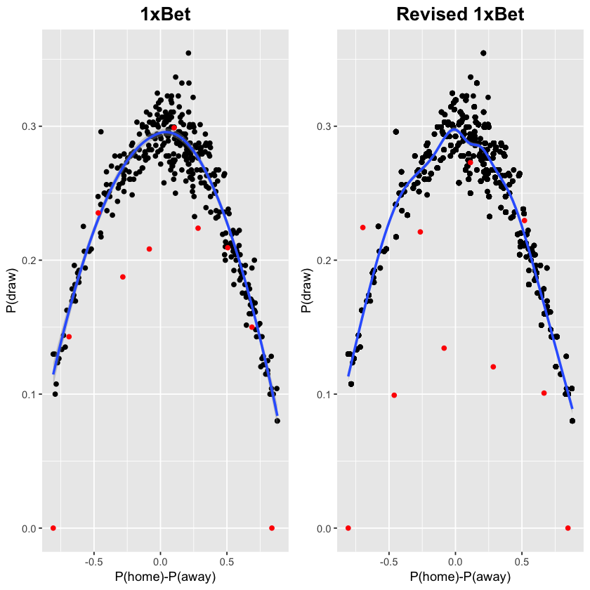

```r
grid.arrange(plot1, revised_plot1, nrow = 1)
```

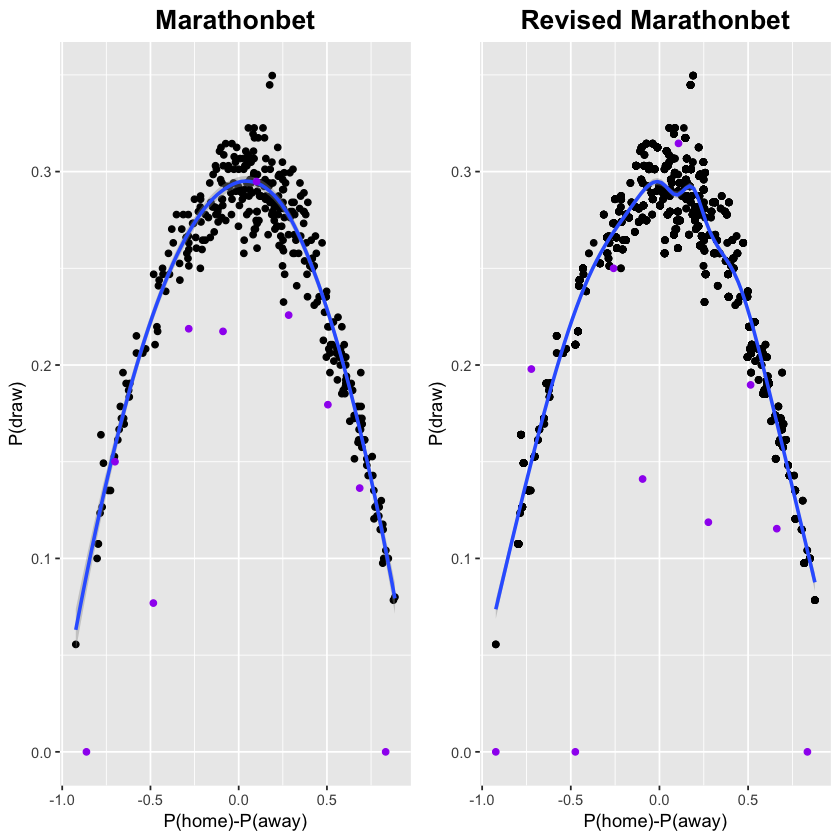

```r
grid.arrange(plot2, revised_plot2, nrow = 1)
```

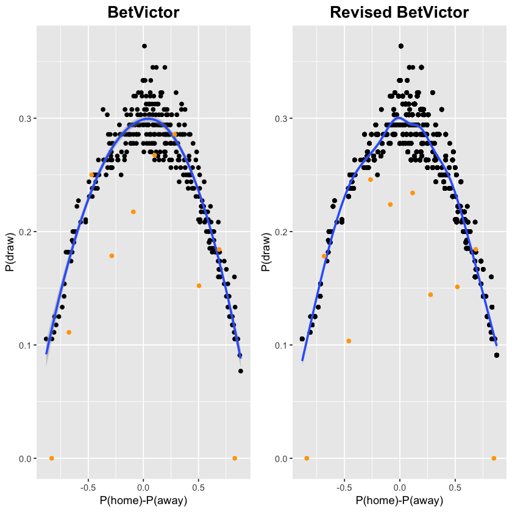

```r
grid.arrange(plot3, revised_plot3, nrow = 1)
```

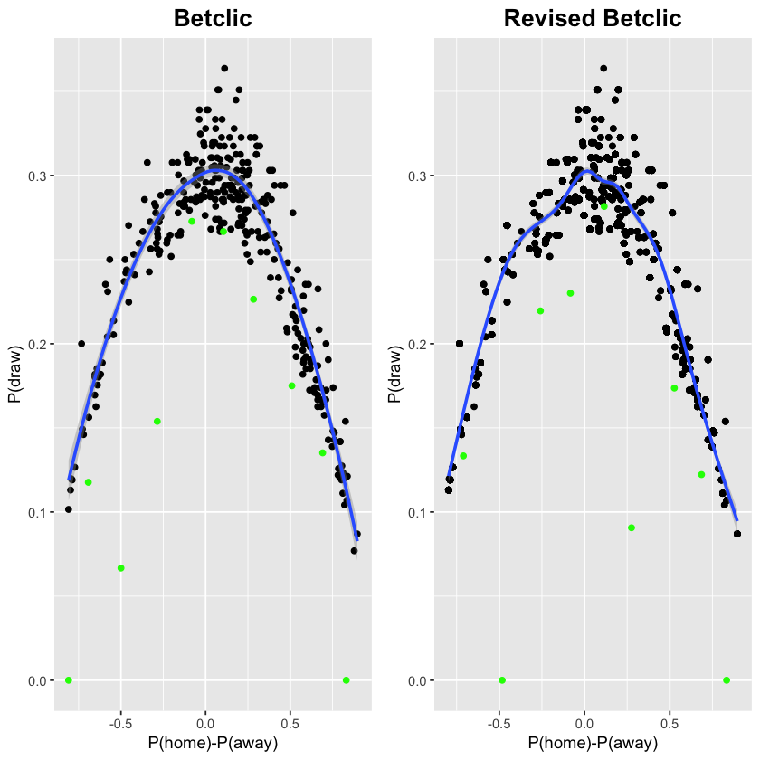

```r
grid.arrange(plot4, revised_plot4, nrow = 1)
```